# Hip_Hop vs. Country

# Step 0. install and load needed libraries

### Step 1. Load the dataset lyrics.RData and generate needed subsets

Get 3 subsets from the file:

1. new.RData - contains both genres, hiphop and country
2. hiphop.RData - contains genre hiphop only
3. country.RData - contains genre country only

### Step 2. Clean data

(Codes from the given Text_Processing.Rmd)

Clean the text by converting all the letters to the lower case, and removing punctuation, numbers, empty words and extra white space, and stem words then generate the corpuses.

### Step 3. Transform corpuses to term document matrix.

Codes from the given InteractiveWordCloud.Rmd

Sava the tdm file as RData

### Step 4. Compare bar charts of the top 10 frequent words in hiphop and country lyrics

Code from [STHDA](http://www.sthda.com/english/wiki/text-mining-and-word-cloud-fundamentals-in-r-5-simple-steps-you-should-know)

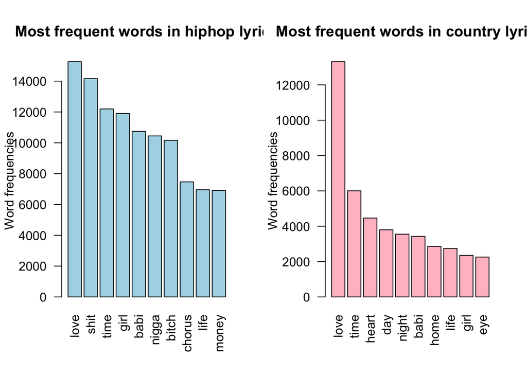

We can see that “love” and “time” are frequently used in both hiphop and country musics. However, by observing the words, the basic tones of two genres seems to be different.

### Step 5. Inspect wordclouds

Codes from the given InteractiveWordCloud.Rmd

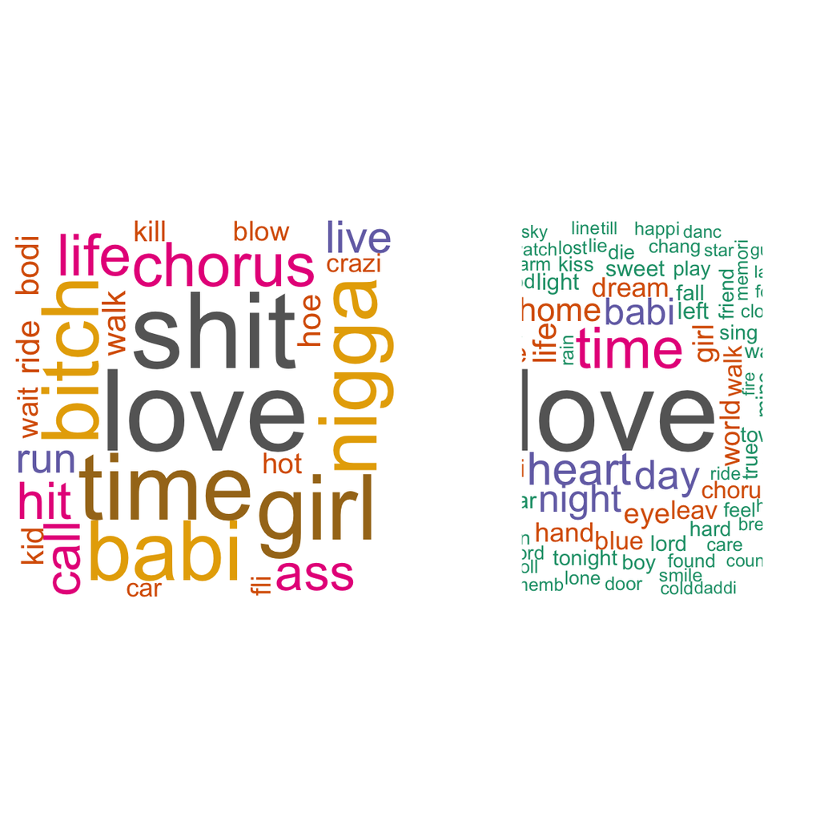

### Step.6 Sentiment Analysis

Code from [Brian Ward](https://towardsdatascience.com/a-light-introduction-to-text-analysis-in-r-ea291a9865a8)

After observing the frequency chart and word cloud, we expect that the sentiment of Hophop is more negative than of Countrys. Let’s do the sentiment analysis and have a look of the scores.

In this step we get the summaries and plots of sentimentGI scores, also top 5 and bottom 5 songs for both genre by the score.

```
##     Min.  1st Qu.   Median     Mean  3rd Qu.     Max.
## -1.00000 -0.08805 -0.03913 -0.02887  0.01676  1.00000
```

The mean and median of the Hiphop sentimentGI score are both negative, which indicates that overall it’s negative.

```
##                          song    sent.h                   song     sent.h
## 1 i-ve-been-trying-travelogue 1.0000000          back-to-front -1.0000000
## 2                     melrose 0.7500000 i-m-not-afraid-no-more -0.5600000
## 3     buy-me-love-money-can-t 0.7254902             mr-ouija-2 -0.5238095
## 4     money-can-t-buy-me-love 0.7254902           fight-for-it -0.5166667
## 5         great-is-your-mercy 0.6923077          broke-it-down -0.5126582
```

The first column are the songs with the five highest sentimentGI score.(Positive) The third column are the songs with the five lowest sentimentGI score.(Negative) It makes sense that those song names are matched with the sentiment.

```
##     Min.  1st Qu.   Median     Mean  3rd Qu.     Max.
## -0.82759 -0.05357  0.03659  0.05000  0.14286  0.90909
```

```
##                          song    sent.c                     song
## 1      you-can-t-be-true-dear 0.9090909 tired-of-waiting-for-you
## 2            it-s-my-pleasure 0.8695652    i-m-not-afraid-to-die
## 3        love-is-worth-living 0.8529412                baby-fall
## 4 i-wish-i-didn-t-love-you-so 0.7647059                same-fool
## 5   my-sweet-blue-eyed-darlin 0.7627119                  runaway
##       sent.c
## 1 -0.8275862
## 2 -0.6666667
## 3 -0.5882353
## 4 -0.5555556
## 5 -0.5319149
```

Similar with the outcome of hiphop, this country song names match with the sentiment

Now visualize it to get more details.

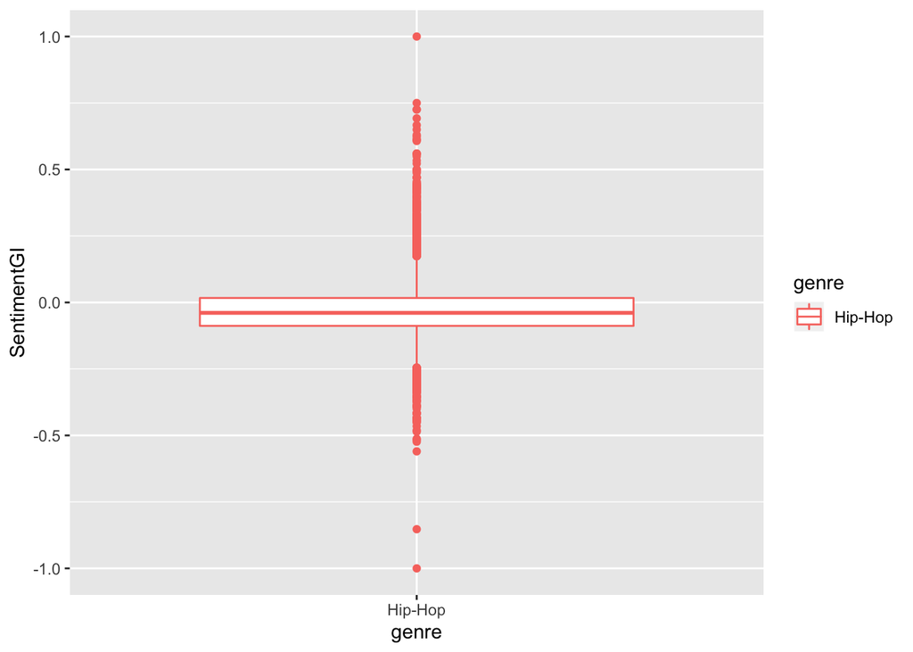

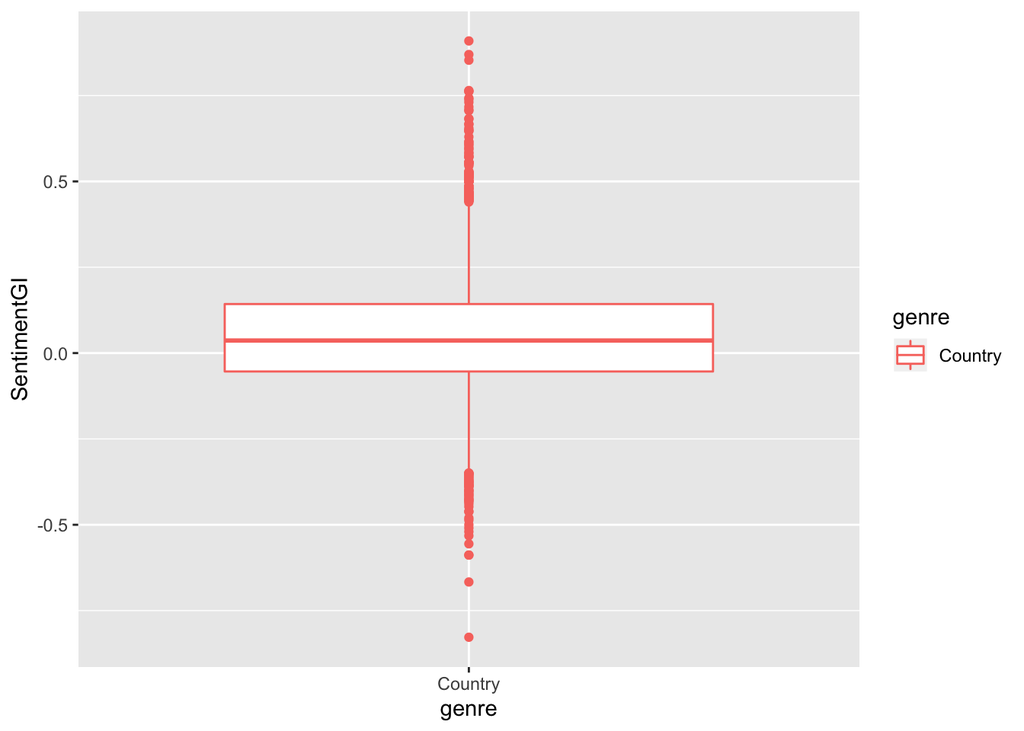

### Step.7 Emotions Analysis

Code from [Brian Ward](https://towardsdatascience.com/a-light-introduction-to-text-analysis-in-r-ea291a9865a8)

In this step we compare the distributions of emotions of hiphop and country lyrics by generating the bar chart.

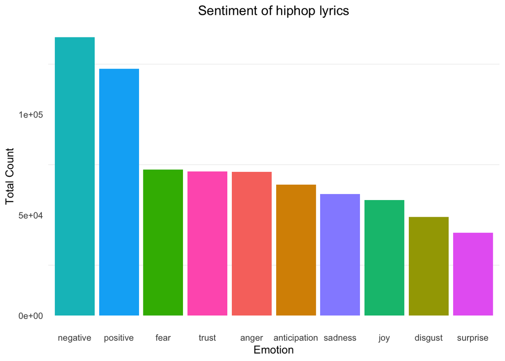

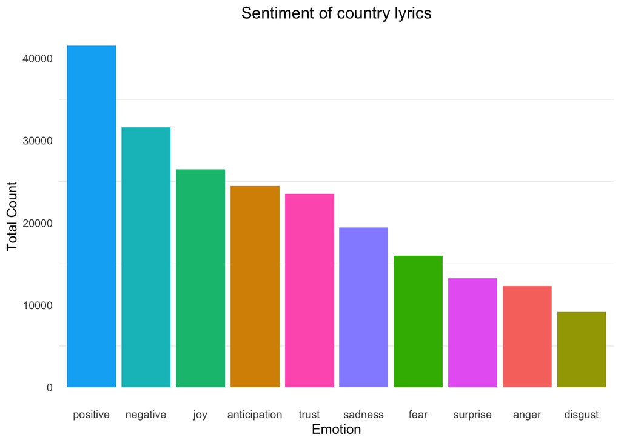

We can see that other than “positive” and “negative”, the most frequently used emotion of hiphop is “fear” whereas for country is “joy”. which is consistent with our guess again.

### Step.8 Topic Modeling

code from [Tutorial(Week 2)](http://tzstatsads.github.io/tutorials/wk2_TextMining.html) and [tidytextmining](https://www.tidytextmining.com/topicmodeling.html#latent-dirichlet-allocation)

The goal is to make a heat map to see if Hiphop and Country lyrics share similar topics.

The dataset used in this step is new.RData. Use method and set k = 5 to get 5 topics from the hiphop and coutry lyrics. First convert the corpus to document term matrix. Then use LDA to get the topics and the terms in each topic by beta value. Then clustering the data frame and make the heat map.

# LDA

[output not shown]

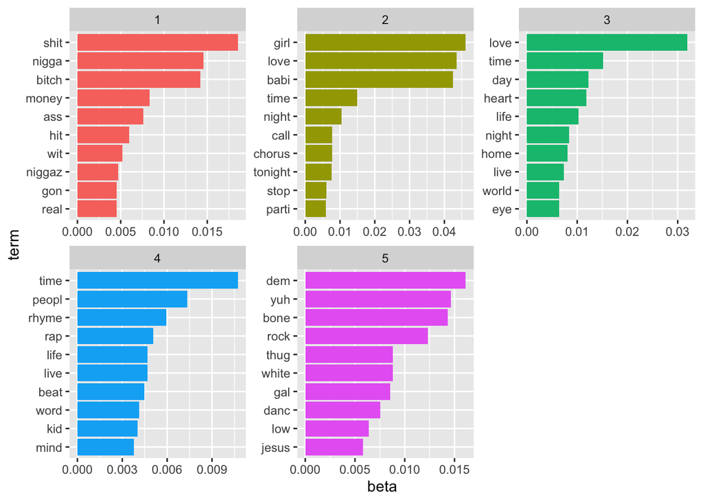

```
##                    song year artist   genre ldatopic ldahash      Topic 1
## 1 when-you-were-with-me 2009      a Hip-Hop        3 Topic 3 0.0039987309
## 2      careless-whisper 2009      a Hip-Hop        3 Topic 3 0.0012828712
## 3                  2-59 2007      a Hip-Hop        4 Topic 4 0.0009857145
## 4       power-of-desire 2007      a Hip-Hop        3 Topic 3 0.0021932652
## 5    you-re-not-in-love 2007      a Hip-Hop        2 Topic 2 0.0024575938
## 6               nothing 2007      a Hip-Hop        3 Topic 3 0.0024001418
##       Topic 2   Topic 3     Topic 4      Topic 5
## 1 0.003999365 0.9840046 0.003998833 0.0039984575
## 2 0.458206158 0.5379447 0.001283123 0.0012831336
## 3 0.297526318 0.2789629 0.421539434 0.0009856063
## 4 0.263872602 0.5986937 0.133047113 0.0021933509
## 5 0.820443323 0.1721839 0.002457856 0.0024573245
## 6 0.002399995 0.9903997 0.002400519 0.0023996803
```

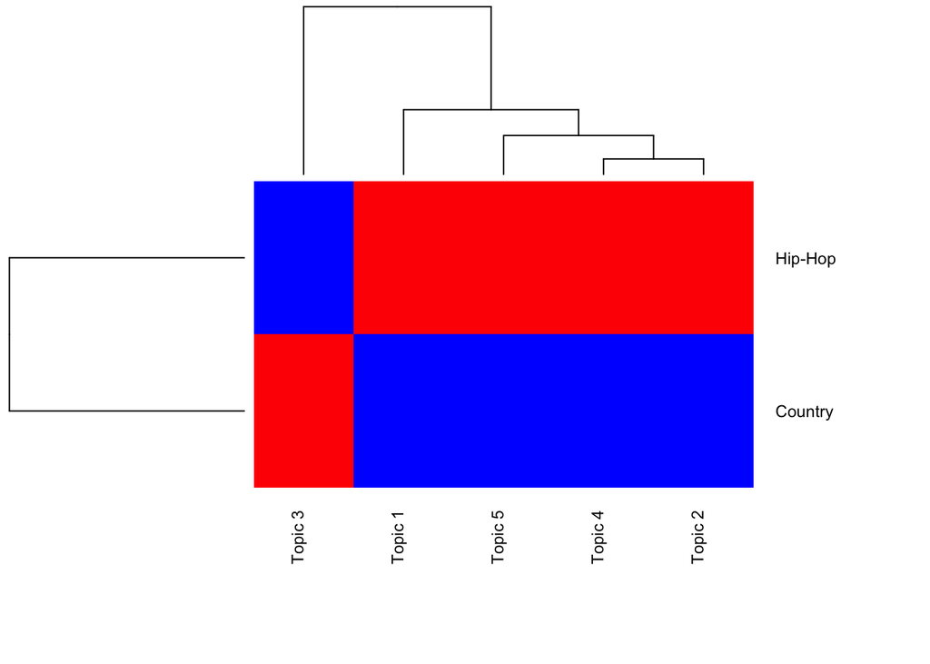

Based on the heat map, it is clear that Hiphop and country lyrics share different topics.

### Conclusion

By observing the word frequency, word cloud, sentimentGI score, emotions distribution and the topics analysis, we can conclude that Hip-hop and Country music lyrics are significantly different.

Hip-hop lyrics tend to be more negative. The words associated with “fear” are used frequently. Whereas Country lyrics are more warm and positive. The words associated with “joy” are used frequently.

Eventhough two genres’ lyrics give different feeling, “Love” is the most popular theme for both.

This conclusion also consistent with our guess by the definitions and cultures.